# Question

Jason drew two overlapping rectangles on a 10x10 grid.

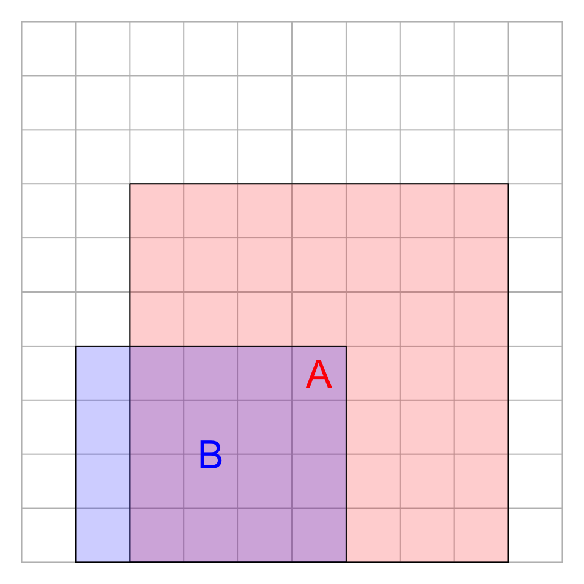

Let’s call the red rectangle A and the blue rectangle B. Find the following areas:

- Area covered by A = ##ANSWER1## squares
- Area covered by B = ##ANSWER2## squares
- Area covered by the intersection of A and B = ##ANSWER3## squares
- Area covered by the union of A and B = ##ANSWER4## squares
- Area covered by ONLY A (and not B) = ##ANSWER5## squares
- Area covered by ONLY B (and not A) = ##ANSWER6## squares
- Area not covered (neither A nor B) = ##ANSWER7## squares

## Answerlist

- 4
- 16
- 20
- 33
- 47
- 49
- 53
- 4
- 16
- 20
- 33
- 47
- 49
- 53
- 4
- 16
- 20
- 33
- 47
- 49
- 53
- 4
- 16
- 20
- 33
- 47
- 49
- 53
- 4
- 16
- 20
- 33
- 47
- 49
- 53
- 4
- 16
- 20
- 33
- 47
- 49
- 53
- 4
- 16
- 20
- 33
- 47
- 49
- 53

# Solution

- Area covered by A = 49
- Area covered by B = 20
- Area covered by the intersection of A and B = 16
- Area covered by the union of A and B = 53
- Area covered by ONLY A (and not B) = 33
- Area covered by ONLY B (and not A) = 4
- Area not covered (neither A nor B) = 47

# Meta-information

extype: cloze exclozetype: schoice|schoice|schoice|schoice|schoice|schoice|schoice exsolution: 0000010|0010000|0100000|0000001|0001000|1000000|0000100 exname: venn_rects